# Analyzing the Effects of Social and Economic Factors on Students’ Dropout and Academic Success

#### 3.12.1 Positively: `AgeEnroll`, `ApplicationMode`, `Debtor`, `Gender`

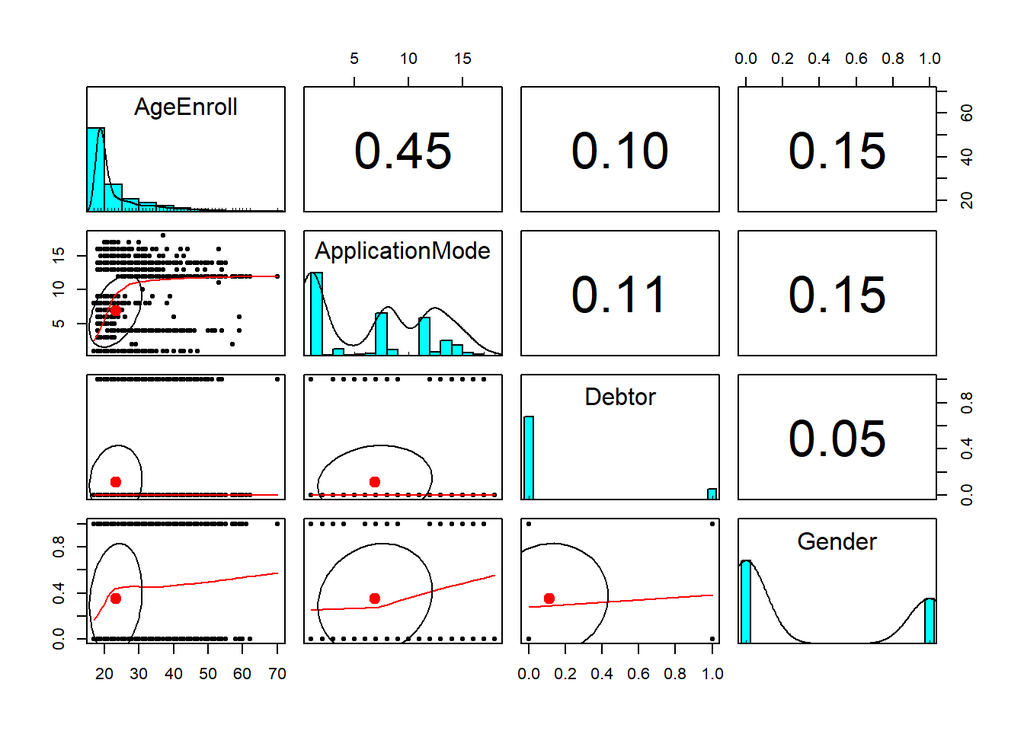

```r
pairs.panels(ac_final[c("AgeEnroll", "ApplicationMode", "Debtor", "Gender")])
```

#### 3.12.2 Negatively: `FirSemGrade`, `Scholarship`, `SecSemEval`, `SecSemGrade`, `TuitionFees`

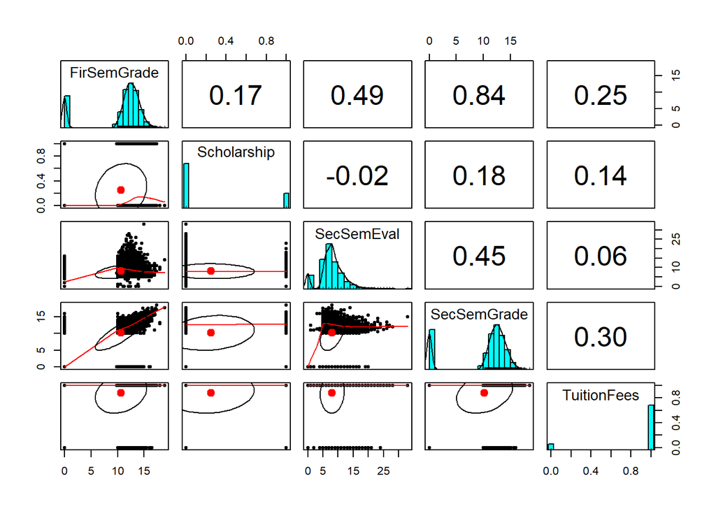

```r
pairs.panels(ac_final[c("FirSemGrade", "Scholarship", "SecSemEval", "SecSemGrade", "TuitionFees")])
```

#### 3.13 Heatmap for `ac_final`

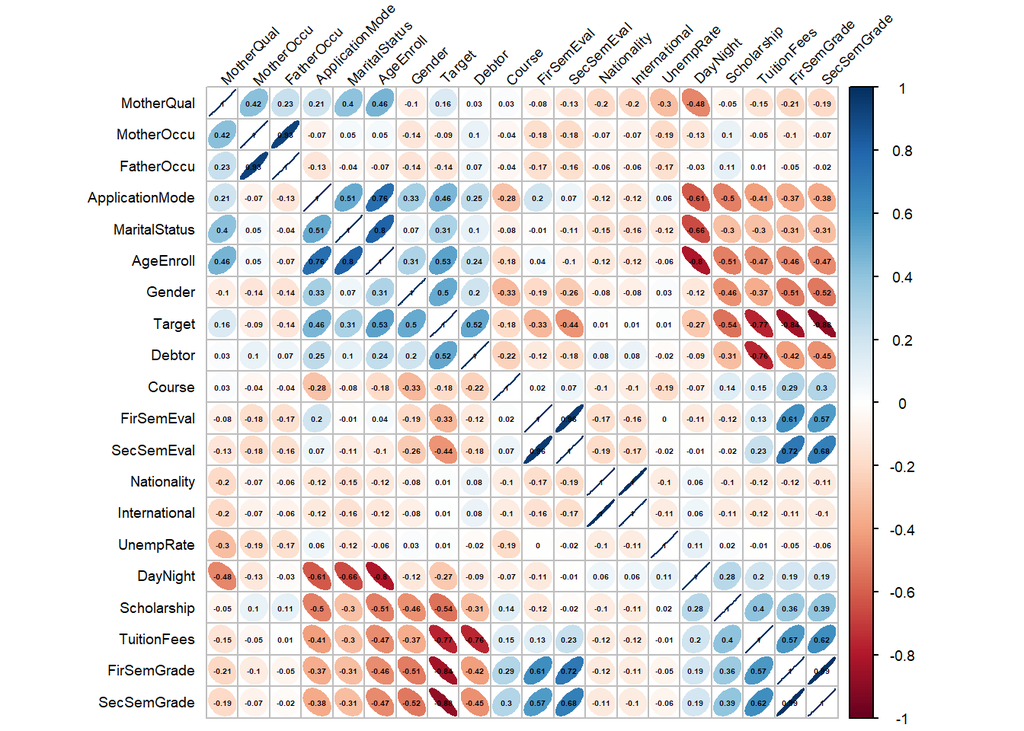

```r
df.cor <- cor(cor_matrix)
corrplot(df.cor, order = "hclust", method = "ellipse",
         tl.col = "black", tl.srt = 45, tl.cex = 0.6,
         cl.cex = 0.6, addCoef.col = "black",
         number.cex = 0.3)
```

#### NOTE: At this point, there are several options to further improve the model:

- 1. Dimension reduction techniques such as Principal Component Regression (PCR) and Cross Validation can be applied.
- 2. More feature engineering can be done such as dealing with outliers and addressing highly correlated variables.
- 3. Hyperparameter tuning can be done based on the selected algorithm.

#### However, for now, I will move on to the model development process to see how each model performs. I can come back later and further develop models.

### —————————————————————————-

# 4. Model Development and Evaluation

#### 4.1 Load library

```r
library(caret)
library(rpart)
library(rpart.plot)
library(tree)
library(randomForest)
library(e1071)
```

#### 4.2 Set Tartget as factor

```r
ac_final$Target <-as.factor(ac_final$Target)
```

#### 4.3 Split a dataset into a training set and a testing set

```r
set.seed(123)
split <- sample(nrow(ac_final), size = 0.7*nrow(ac_final))

ac_train <- ac_final[split,]
ac_test <- ac_final[-split,]
```

#### —————————————————————————

### 4.4 Logistic Regression Model

```r
logi_model <- glm(Target ~ ., data = ac_train, family = "binomial")
summary(logi_model)
```

```
##
## Call:
## glm(formula = Target ~ ., family = "binomial", data = ac_train)
##
## Deviance Residuals:
##     Min       1Q   Median       3Q      Max
## -3.2384  -0.5621  -0.3512   0.3318   2.9324
##
## Coefficients:
##                  Estimate Std. Error z value Pr(>|z|)
## (Intercept)      1.756124   0.454955   3.860 0.000113 ***
## MaritalStatus   -0.228335   0.101335  -2.253 0.024243 *
## ApplicationMode  0.026506   0.011633   2.279 0.022693 *
## Course           0.102087   0.012812   7.968 1.61e-15 ***
## DayNight         0.237454   0.187040   1.270 0.204250
## Nationality      0.111038   0.084241   1.318 0.187468
## MotherQual       0.017072   0.006786   2.516 0.011874 *
## MotherOccu      -0.050907   0.021325  -2.387 0.016974 *
## FatherOccu      -0.025479   0.018363  -1.388 0.165280
## Debtor           0.646970   0.179267   3.609 0.000307 ***
## TuitionFees     -2.371241   0.191516 -12.381  < 2e-16 ***
## Gender           0.384587   0.111942   3.436 0.000591 ***
## Scholarship     -0.839103   0.149461  -5.614 1.97e-08 ***
## AgeEnroll        0.040280   0.009258   4.351 1.36e-05 ***
## International   -2.004313   0.968206  -2.070 0.038440 *
## FirSemEval       0.047978   0.020407   2.351 0.018717 *
## FirSemGrade     -0.052604   0.021526  -2.444 0.014533 *
## SecSemEval       0.039261   0.022403   1.753 0.079686 .
## SecSemGrade     -0.258061   0.020072 -12.857  < 2e-16 ***
## UnempRate        0.002682   0.020078   0.134 0.893721
## ---
## Signif. codes:  0 '***' 0.001 '**' 0.01 '*' 0.05 '.' 0.1 ' ' 1
##
## (Dispersion parameter for binomial family taken to be 1)
##
##     Null deviance: 3877.5  on 3095  degrees of freedom
## Residual deviance: 2290.6  on 3076  degrees of freedom
## AIC: 2330.6
##
## Number of Fisher Scoring iterations: 5
```